# ECON 339 - Tuesday/Thursday Week 6

- Show All Code
- Hide All Code
- View Source

Author

Matina Lampsas

Published

May 9, 2024

# Setup

```r
library(tidyverse)
library(readxl)
options(scipen = 999)
```

# Tuesday Notes

## Read in the Data

```r
#read in the data for the wages
wages_data <- read_xlsx(here::here("data",
                     "Data for Weeks 2-7.xlsx"),
                      sheet = "Wages"
                     )
```

## In Class Example:

### Make a scatter plot:

Plot Wage against Age and evaluate whether a linear or quadratic regression model better captures the relationship. Verify your choice by using the appropriate goodness-of-fit measure.

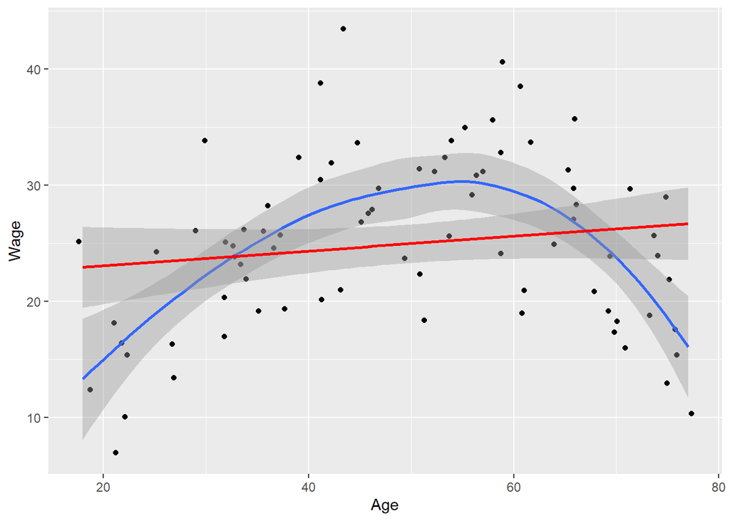

```r
wages_data %>%
  ggplot(aes(x = Age, y = Wage))+
  geom_jitter()+
  geom_smooth()+
  geom_smooth(method = "lm", color = "red")
```

- On the exam, he will ask us to do graphs

```r
wages_data <- wages_data %>%
  mutate(age_sqrd = Age^2)
wages_lm <- lm(Wage ~ Age + Educ ,data = wages_data)
summary(wages_lm)
```

```
Call:
lm(formula = Wage ~ Age + Educ, data = wages_data)

Residuals:
     Min       1Q   Median       3Q      Max
-13.2598  -1.9734   0.3785   2.7700   9.9533

Coefficients:
            Estimate Std. Error t value            Pr(>|t|)
(Intercept)  2.63808    2.36649   1.115               0.268
Age          0.04717    0.03062   1.541               0.127
Educ         1.44101    0.13123  10.981 <0.0000000000000002 ***
---
Signif. codes:  0 '***' 0.001 '**' 0.01 '*' 0.05 '.' 0.1 ' ' 1

Residual standard error: 4.678 on 77 degrees of freedom
Multiple R-squared:  0.6187,    Adjusted R-squared:  0.6088
F-statistic: 62.47 on 2 and 77 DF,  p-value: < 0.00000000000000022
```

```r
wages_qm <- lm(Wage ~ Educ+ Age + I(Age^2), data = wages_data)
summary(wages_qm)
```

```
Call:
lm(formula = Wage ~ Educ + Age + I(Age^2), data = wages_data)

Residuals:
    Min      1Q  Median      3Q     Max
-8.7285 -1.7124 -0.3596  1.9203  7.8048

Coefficients:
              Estimate Std. Error t value             Pr(>|t|)
(Intercept) -22.721936   3.022859  -7.517  0.00000000009217113 ***
Educ          1.253959   0.089631  13.990 < 0.0000000000000002 ***
Age           1.350002   0.133973  10.077  0.00000000000000119 ***
I(Age^2)     -0.013322   0.001354  -9.840  0.00000000000000334 ***
---
Signif. codes:  0 '***' 0.001 '**' 0.01 '*' 0.05 '.' 0.1 ' ' 1

Residual standard error: 3.123 on 76 degrees of freedom
Multiple R-squared:  0.8323,    Adjusted R-squared:  0.8257
F-statistic: 125.7 on 3 and 76 DF,  p-value: < 0.00000000000000022
```

### Predict Vals:

```r
predict(wages_qm, data.frame(Educ=16, Age=30))
```

```
       1
25.85187
```

```r
predict(wages_qm, data.frame(Educ=16, Age=50))
```

```
       1
31.53709
```

```r
predict(wages_qm, data.frame(Educ=16, Age=70))
```

```
      1
26.5649
```

### Make visualization:

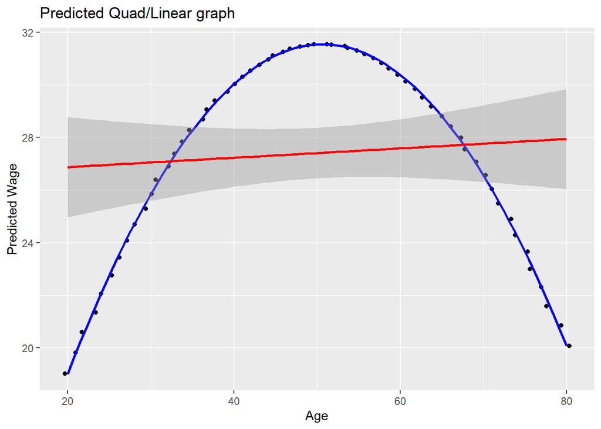

```r
coeffs <- coefficients(wages_qm)
predict <- map2_df(.x = 20:80,
                   .y= 16,
                   .f = ~predict(wages_qm, data.frame(Educ = .y, Age = .x)))
predict %>%
  mutate(age = 20:80) %>%
  rename(pred_wage = `1`) %>%
  ggplot(aes(x = age, y = pred_wage)) +
  geom_jitter() +
  geom_smooth(color = "blue", aes(group = "Quadratic Model")) +  # Labeling the blue line as quadratic
  geom_smooth(method = "lm", color = "red", aes(group = "Linear Model")) +  # Labeling the red line as linear
  labs(title = "Predicted Quad/Linear graph", x = "Age", y = "Predicted Wage", color = "Model Key")
```

## Practice Question:

### Import the Data:

```r
#read in the data for the tech sales
techsales_data <- read_xlsx(here::here("data",
                     "Data for Weeks 2-7.xlsx"),
                      sheet = "TechSales"
                     )
```

### Subsest the data and make dummy variables:

First subset the TechSales data to include only hardware product. You should obtain 9860 observations. Use College and Personality variables to construct appropriate dummy variables.

```r
filtered_tchsales <- techsales_data %>%
  filter(Business == "Hardware") %>%
  mutate(d1 = if_else(Personality == "Diplomat",1,0),
         d2 = if_else(Personality == "Explorer", 1,0),
         d3 = if_else(Personality == "Analyst",1,0),
         d4 = if_else(Personality == "Sentinel",1,0),
         d5 = if_else(College =="Yes", 1,0))
```

Compare the linear model (Model 1) that uses Age, Female, College, Analyst, Diplomat, Explorer, and Certificates as predictor variables. Model 2 extends Model 1 by including age-sq as an additional predictor variable

```r
# make a model that isn't quadratic
model_1 <- lm(NPS ~ Age + Female +Certificates + d1 + d2 + d3 + d5, data = filtered_tchsales)
# make a quadratic model that considers Age ^2
model_2 <- lm(NPS ~ Age + Female +Certificates+ d1 + d2 + d3 + d5 + I(Age^2), data = filtered_tchsales)
# summarize and compare the models
summary(model_1) ; summary(model_2)
```

```
Call:
lm(formula = NPS ~ Age + Female + Certificates + d1 + d2 + d3 +
    d5, data = filtered_tchsales)

Residuals:
    Min      1Q  Median      3Q     Max
-4.7915 -1.2386 -0.0851  1.1912  5.9559

Coefficients:
             Estimate Std. Error t value             Pr(>|t|)
(Intercept)  2.668109   0.089713  29.740 < 0.0000000000000002 ***
Age          0.005776   0.001447   3.992             0.000066 ***
Female       0.108935   0.036366   2.996              0.00275 **
Certificates 0.599336   0.010590  56.595 < 0.0000000000000002 ***
d1           1.944400   0.053409  36.406 < 0.0000000000000002 ***
d2           1.961001   0.053044  36.969 < 0.0000000000000002 ***
d3           0.070719   0.066947   1.056              0.29084
d5           0.499414   0.041301  12.092 < 0.0000000000000002 ***
---
Signif. codes:  0 '***' 0.001 '**' 0.01 '*' 0.05 '.' 0.1 ' ' 1

Residual standard error: 1.708 on 9852 degrees of freedom
Multiple R-squared:  0.3665,    Adjusted R-squared:  0.366
F-statistic: 814.2 on 7 and 9852 DF,  p-value: < 0.00000000000000022
```

```
Call:
lm(formula = NPS ~ Age + Female + Certificates + d1 + d2 + d3 +
    d5 + I(Age^2), data = filtered_tchsales)

Residuals:
    Min      1Q  Median      3Q     Max
-4.7515 -1.2344 -0.0857  1.1972  5.8852

Coefficients:
               Estimate Std. Error t value             Pr(>|t|)
(Intercept)   1.6831207  0.2666131   6.313       0.000000000286 ***
Age           0.0533838  0.0122219   4.368       0.000012673362 ***
Female        0.1069090  0.0363430   2.942              0.00327 **
Certificates  0.5991804  0.0105823  56.621 < 0.0000000000000002 ***
d1            1.9427726  0.0533712  36.401 < 0.0000000000000002 ***
d2            1.9619669  0.0530057  37.014 < 0.0000000000000002 ***
d3            0.0713545  0.0668986   1.067              0.28618
d5            0.5015599  0.0412745  12.152 < 0.0000000000000002 ***
I(Age^2)     -0.0005345  0.0001363  -3.923       0.000088097919 ***
---
Signif. codes:  0 '***' 0.001 '**' 0.01 '*' 0.05 '.' 0.1 ' ' 1

Residual standard error: 1.707 on 9851 degrees of freedom
Multiple R-squared:  0.3675,    Adjusted R-squared:  0.367
F-statistic: 715.4 on 8 and 9851 DF,  p-value: < 0.00000000000000022
```

• Use model selection criteria to find the appropriate model for the analysis. • Interpret your results with reference to well-formatted figures and tables.

```r
# Extract coefficients and standard errors
summary_df <- broom::tidy(model_1) %>%
  select(term, estimate, std.error) %>%
  rename(Variable = term, Coefficient = estimate, `Std. Error` = std.error)




# Print or display the summary table
print(summary_df)
```

```
# A tibble: 8 × 3
  Variable     Coefficient `Std. Error`
  <chr>              <dbl>        <dbl>
1 (Intercept)      2.67         0.0897
2 Age              0.00578      0.00145
3 Female           0.109        0.0364
4 Certificates     0.599        0.0106
5 d1               1.94         0.0534
6 d2               1.96         0.0530
7 d3               0.0707       0.0669
8 d5               0.499        0.0413
```

The second model will be chosen since the R^2 value is larger and theremore more accurate

### Second Part of Practice Question:

Create a plot to highlight the quadratic effect of age. For the plot, use age between 30-60, using a female graduate analyst with 3 certificates

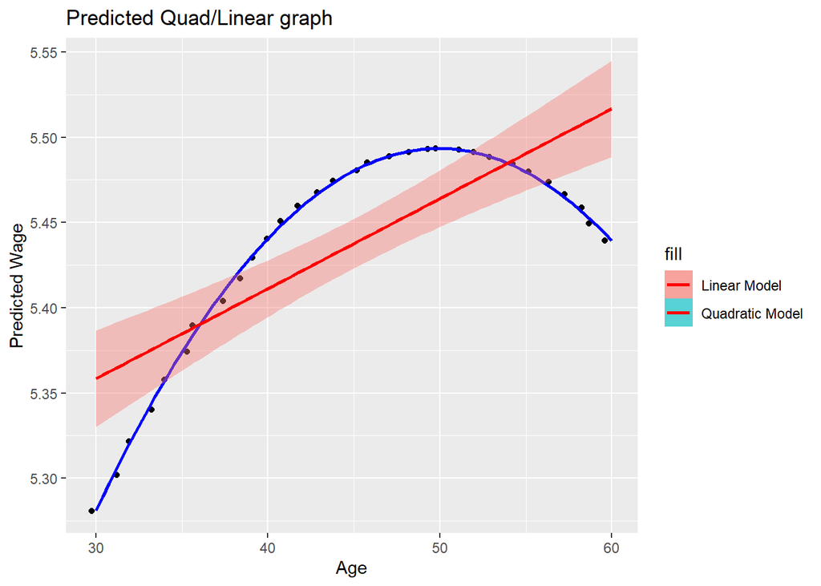

```r
# predict the values
predict_2 <- map_df(.x = 30:60,
                    .f = ~predict(model_2, data.frame(Age = .x,
                                                      Female = 1,
                                                      d1 = 0,
                                                      d2 = 0,
                                                      d3 = 1,
                                                      d5 = 1,
                                                      Certificates = 3
                                                      )
                                  )
                    )

predict_2 %>%
  # add an age column to the data
  mutate(age = 30:60) %>%
  #rename the column from the predicted varaible
  rename(pred_NPS = `1`) %>%
  # make the visualization
  ggplot(aes(x = age, y = pred_NPS)) +
  geom_jitter() +
  geom_smooth(color = "blue",aes( fill = "Quadratic Model")) +  # Labeling the blue line as quadratic
  geom_smooth(method = "lm", color = "red", aes(fill = "Linear Model")) +  # Labeling the red line as linear
  labs(title = "Predicted Quad/Linear graph", x = "Age", y = "Predicted Wage", color = "Model Key")
```

# Thursday notes

## Import data

```r
#read in the data for the wages
collegetwn_data <- read_xlsx(here::here("data",
                     "Data for Weeks 2-7.xlsx"),
                      sheet = "CollegeTown"
                     )
```

## In Class Example:

### Make a scatter plot:

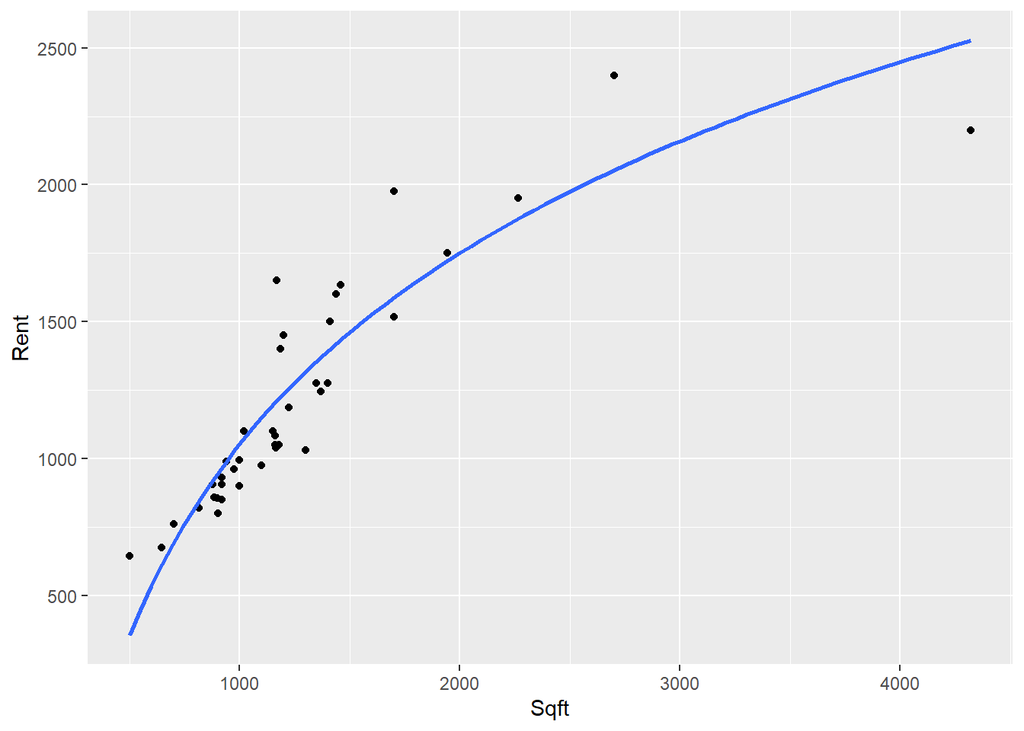

```r
# visualize the data - using log transformation
collegetwn_data %>%
  ggplot(aes(x = Sqft, y = Rent))+
  geom_jitter()+
  geom_smooth(method = "lm",
              formula = y ~ log(x),
              se = FALSE)
```

** Review the way of doing it on excel **

### Make your models

```r
# Model 1 -- standard linear model:
college_lm <- lm(Rent ~ Beds + Baths + Sqft, data = collegetwn_data)

# Model 2 -- log the sqft and keeping the others constant
college_lm2 <- lm(Rent ~ Beds + Baths + log(Sqft), data = collegetwn_data)

# Model 3 -- log the rent only and keeping the others constant
college_lm3 <- lm(log(Rent) ~ Beds + Baths + Sqft, data = collegetwn_data)

# Model 4 -- log the Sqft AND rent and keeping the others constant
college_lm4 <- lm(log(Rent) ~ Beds + Baths + log(Sqft), data = collegetwn_data)
```

### Made predictions using your models:

#### Use model 1 & 2 to make predictions

```r
#use model 1 to make a prediction with sqft = 1600, Beds = 3, and Baths = 2
predict(college_lm, data.frame(Beds = 3,
                               Baths = 2,
                               Sqft = 1600))
```

```
      1
1491.69
```

```r
#use model 2 to make a prediction with sqft = 1600, Beds = 3, and Baths = 2
predict(college_lm2, data.frame(Beds = 3,
                               Baths = 2,
                               Sqft = 1600))
```

```
       1
1540.384
```

#### Use model 3 to make prediction

```r
# use the model 3 to predict
# since rent (y) is logged, you need to compute the se in order to predicti: use the following steps

predi_log_3 <- predict(college_lm3, data.frame(Beds = 3,
                                               Baths = 2,
                                               Sqft = 1600))

# extract the standard error of the linear model
se_3 <- sigma(college_lm3)
# use the standard error and you prediction in order to predict that value
prediction_model_3 <- exp(predi_log_3 + se_3^2/2)

prediction_model_3
```

```
       1
1463.207
```

#### Use model 4 to make prediction

```r
# use the model 4 to predict
# since rent (y) is logged, you need to compute the se in order to predicti: use the following steps
predi_log_4 <- predict(college_lm4, data.frame(Beds = 3,
                                               Baths = 2,
                                               Sqft = 1600))
# extract the standard error of the linear model
se_4 <- sigma(college_lm4)
# use the standard error and you prediction in order to predict that value
prediction_model_4 <- exp(predi_log_4 + se_3^2/2)

prediction_model_4
```

```
      1
1502.58
```

```r
# computing Rsq for model 4;
predict_lnrent <- predict(college_lm4)
stde_4 <- sigma(college_lm4)
pred_rent <- exp(predict_lnrent+stde_4^2/2)
cor(collegetwn_data$Rent, pred_rent)^2
```

```
[1] 0.7554188
```

#### Write a function to compute R^2:

```r
compute_r_squared <- function(model, var, data) {
  # Compute predicted log value
  predict_lnval <- predict(model)

  # Compute standard error of the model
  stde <- sigma(model)

  # Compute predicted value
  pred_val <- exp(predict_lnval + stde^2 / 2)

  # Compute R-squared
  r_squared <- cor(data[[var]], pred_val)^2

  return(r_squared)
}

# Example usage:
# Replace 'college_lm4' with your actual linear model and 'collegetwn_data' with your dataset
result <- compute_r_squared(model = college_lm4, var = "Rent", data = collegetwn_data)
cat("R-squared for model 4:", result, "\n")
```

```
R-squared for model 4: 0.7554188
```

## Class Practice Problems

### Problem 2:

2. A business division is a part of a company that is responsible for a specific product, service, or market. Business divisions are often set up to allow a company to focus on a particular area of its operations and to operate more efficiently. The accompanying data file includes employee salary (Salary, in $1,000s), business division (Marketing, Development, or Customer Service) and college education (Yes or No). Data: Division.

```r
#read in the data for the wages
division_data <- read_xlsx(here::here("data",
                     "Data for Weeks 2-7.xlsx"),
                      sheet = "Division"
                     )
```

#### Part 1:

• Use the appropriate dummy variables to estimate a linear regression model for salary using business division and college education as predictor variables. Use the estimated model to predict the salaries of college educated employees in each of the three divisions.

```r
# Make dummy varaiables
division_data <- division_data %>%
  mutate(d1 = if_else(Division == "Marketing",1,0),
         d2 = if_else(Division == "Development", 1,0),
         d3 = if_else(Division == "Customer Service",1,0),
         d4 = if_else(College =="Yes", 1,0))

# estimate a linear regression model for salary using business division and college education as predictor variables
division_lm <- lm(Salary ~ d1 +d2 + d4, data = division_data)
# summary(division_lm)

#use the model to predict the salary of college educated employees in each of the three divisions
## prediction for marketing
predict(division_lm, data.frame(d1 = 1, d2=0, d4=1))
```

```
      1
118.372
```

```r
## prediction for development
predict(division_lm, data.frame(d1 = 0, d2=1, d4=1))
```

```
       1
116.9335
```

```r
## prediction for customer service
predict(division_lm, data.frame(d1 = 0, d2=0, d4=1))
```

```
       1
99.73251
```

#### Part 2:

```r
# Write function to do prediction easy:
predict_and_calculate <- function(d1, d2, d4, model) {
  # Predict the log value
  predi_log <- predict(model, newdata = data.frame(d1 = d1, d2 = d2, d4 = d4))

  # Extract the standard error
  se <- sigma(model)

  # Calculate the final prediction
  prediction <- exp(predi_log + se^2 / 2)

  return(prediction)
}
```

```r
# estimate a linear model for salary using exponential model that uses ln(Salary as response)
division_exp <- lm(log(Salary) ~ d1 +d2 + d4, data = division_data)


predict_and_calculate(d1 = 1, d2 = 0, d4 = 1, model = division_exp)
```

```
       1
119.2633
```

```r
predict_and_calculate(d1 = 0, d2 = 1, d4 = 1, model = division_exp)
```

```
       1
118.4985
```

```r
predict_and_calculate(d1 = 0, d2 = 1, d4 = 1, model = division_exp)
```

```
       1
118.4985
```

#### Part 3:

```r
# we need to calculate R^2 if we want to compare the models
compute_r_squared(model = division_exp, var = "Salary", data = division_data)
```

```
[1] 0.3071501
```